# WGCNA in Proteomic data. Shared proteins norm

# 1 Data input, cleaning and pre-processing

Load protein abundance data, pre-process them into a format suitable for network analysis, and clean the data by removing obvious outlier samples as well as proteins and samples with excessive numbers of missing entries.

## 1.a Loading expression data

The expression data is contained in the files:

- 1-9_A1_A2_A3__precol2cm_col75cm_top15_70000_3e6_50_35000_5e4_100_iw4_excl40_2h_200nlmin_1ul_A1vsA2vsA3.xlsx that comes with this tutorial.
- 10-14_C1_C2_C3__precol2cm_col75cm_top15_70000_3e6_50_35000_5e4_100_iw4_excl40_2h_200nlmin_1ul_C1vsC2vsC3.xlsx

These files contains several quality parametres. We have used grouped protein abundance to compare samples.

Files not share same proteins, this is one important point to discuss. One aporximation is consider missing protein with 0 abundance. Also it can be considered only the shared proetins.

```r
library(readxl)

# Load the WGCNA package
library(WGCNA);
# The following setting is important, do not omit.
options(stringsAsFactors = FALSE)
#Read in the female liver data set
pheno<-read_excel("./nomenclatura.xlsx")
# Take a quick look at what is in the data set:
dim(pheno)
```

```
## [1] 6 3
```

```r
names(pheno)
```

```
## [1] "Nomenclatura Raw Data"         "Nomenclatura mostres de miRNA"
## [3] "Nomenclatura unificada"
```

```r
load("RESULTATS/OBJECTES/data_abundance")
datExpr0 = as.data.frame(data_abundance)[complete.cases(as.data.frame(data_abundance)),]


rownames(datExpr0) = datExpr0$Row.names
datExpr0<-datExpr0[,-1]
datExpr0<-t(datExpr0)
```

## 1.b Checking data for excessive missing values and identification of outlier microarray samples

We first check for proteins and samples with too many missing values:

```r
gsg = goodSamplesGenes(datExpr0, verbose = 3);
```

```
##  Flagging genes and samples with too many missing values...
##   ..step 1
```

```r
gsg$allOK
```

```
## [1] TRUE
```

```r
if (!gsg$allOK)
{
# Optionally, print the gene and sample names that were removed:
if (sum(!gsg$goodGenes)>0)
printFlush(paste("Removing genes:", paste(names(datExpr0)[!gsg$goodGenes], collapse = ", ")));
if (sum(!gsg$goodSamples)>0)
printFlush(paste("Removing samples:", paste(rownames(datExpr0)[!gsg$goodSamples], collapse = ", ")));
# Remove the offending genes and samples from the data:
datExpr0 = datExpr0[gsg$goodSamples, gsg$goodGenes]
}
```

Next we cluster the samples (in contrast to clustering proteins that will come later) to see if there are any obvious outliers.

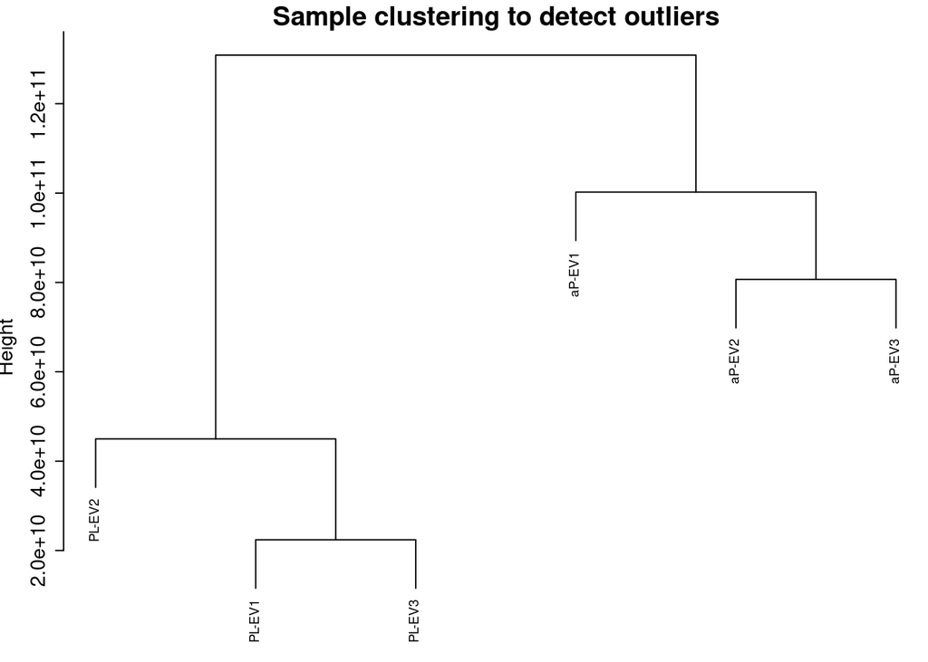

```r
sampleTree = hclust(dist(datExpr0), method = "average");
# Plot the sample tree: Open a graphic output window of size 12 by 9 inches
# The user should change the dimensions if the window is too large or too small.
# sizeGrWindow(12,9)
#pdf(file = "Plots/sampleClustering.pdf", width = 12, height = 9);
par(cex = 0.6);
par(mar = c(0,4,2,0))
plot(sampleTree, main = "Sample clustering to detect outliers", sub="", xlab="", cex.lab = 1.5,
cex.axis = 1.5, cex.main = 2)
```

## 1.c Loading clinical trait data

```r
pheno<-read_excel("./nomenclatura.xlsx")
dim(pheno)
```

```
## [1] 6 3
```

```r
names(pheno)
```

```
## [1] "Nomenclatura Raw Data"         "Nomenclatura mostres de miRNA"
## [3] "Nomenclatura unificada"
```

```r
pheno$grup<-as.factor(c("NaCl","NaCl","NaCl","PR","PR","PR"))
# remove columns that hold information we do not need.
allTraits = data.frame(pheno)

dim(allTraits)
```

```
## [1] 6 4
```

```r
names(allTraits)
```

```
## [1] "Nomenclatura.Raw.Data"         "Nomenclatura.mostres.de.miRNA"
## [3] "Nomenclatura.unificada"        "grup"
```

```r
# Form a data frame analogous to expression data that will hold the clinical traits.
nameSamples = rownames(datExpr0);
traitRows = match(nameSamples, allTraits$Nomenclatura.unificada);
datTraits = allTraits[traitRows,];
rownames(datTraits) = allTraits[traitRows, 1];
collectGarbage()
```

We now have the expression data in the variable datExpr, and the corresponding clinical traits in the variable datTraits.

## Sample dendrogram

Before we continue with network construction and module detection, we visualize how the clinical traits relate to the sample dendrogram

```r
# Re-cluster samples
sampleTree2 = hclust(dist(datExpr0), method = "average")
# Convert traits to a color representation: white means low, red means high, grey means missing entry
datTraits
```

```
##    Nomenclatura.Raw.Data Nomenclatura.mostres.de.miRNA Nomenclatura.unificada
## C1                    C1                          PRP1                 aP-EV1
## C2                    C2                          PRP2                 aP-EV2
## C3                    C3                          PRP3                 aP-EV3
## A1                    A1                         NaCl1                 PL-EV1
## A2                    A2                         NaCl2                 PL-EV2
## A3                    A3                         NaCL3                 PL-EV3
##    grup
## C1   PR
## C2   PR
## C3   PR
## A1 NaCl
## A2 NaCl
## A3 NaCl
```

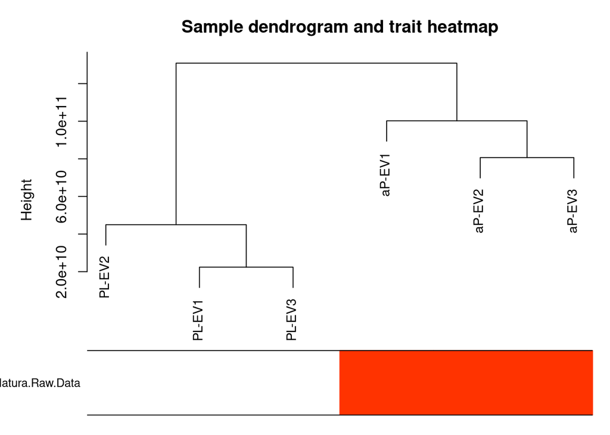

```r
traitColors = numbers2colors(as.numeric(datTraits$grup), signed = FALSE);
# Plot the sample dendrogram and the colors underneath.
plotDendroAndColors(sampleTree2, traitColors,
groupLabels = names(datTraits),
main = "Sample dendrogram and trait heatmap")
```

# Batch effect?

Groups are very different (between other things, are not share proteins).

```r
library(sva)
row.names(datExpr0)
```

```
## [1] "aP-EV1" "aP-EV2" "aP-EV3" "PL-EV1" "PL-EV2" "PL-EV3"
```

```r
datExpr0<-
ComBat(
  t(datExpr0),batch = c(rep("ap",3),rep("PL",3)),
  mod = NULL,
  par.prior = TRUE,
  prior.plots = FALSE,
  mean.only = FALSE,
  ref.batch = NULL,
  BPPARAM = bpparam("SerialParam")
)
```

```
## Found2batches
```

```
## Adjusting for0covariate(s) or covariate level(s)
```

```
## Standardizing Data across genes
```

```
## Fitting L/S model and finding priors
```

```
## Finding parametric adjustments
```

```
## Adjusting the Data
```

```r
datExpr0<-t(datExpr0)
```

## Sample dendrogram

Before we continue with network construction and module detection, we visualize how the clinical traits relate to the sample dendrogram

```r
# Re-cluster samples
sampleTree2 = hclust(dist(datExpr0), method = "average")
# Convert traits to a color representation: white means low, red means high, grey means missing entry
datTraits
```

```
##    Nomenclatura.Raw.Data Nomenclatura.mostres.de.miRNA Nomenclatura.unificada
## C1                    C1                          PRP1                 aP-EV1
## C2                    C2                          PRP2                 aP-EV2
## C3                    C3                          PRP3                 aP-EV3
## A1                    A1                         NaCl1                 PL-EV1
## A2                    A2                         NaCl2                 PL-EV2
## A3                    A3                         NaCL3                 PL-EV3
##    grup
## C1   PR
## C2   PR
## C3   PR
## A1 NaCl
## A2 NaCl
## A3 NaCl
```

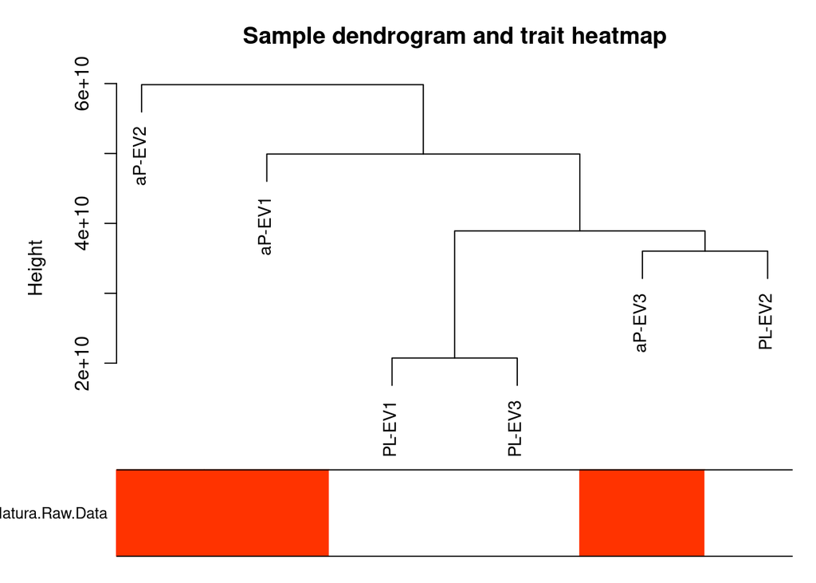

```r
traitColors = numbers2colors(as.numeric(datTraits$grup), signed = FALSE);
# Plot the sample dendrogram and the colors underneath.
plotDendroAndColors(sampleTree2, traitColors,
groupLabels = names(datTraits),
main = "Sample dendrogram and trait heatmap")
```

# 2.1 Automatic network construction and module detection

## 2.a.1 Choosing the soft-thresholding power: analysis of network topology

Constructing a weighted gene network entails the choice of the soft thresholding power β to which co-expression similarity is raised to calculate adjacency [1]. The authors of [1] have proposed to choose the soft thresholding power based on the criterion of approximate scale-free topology. We refer the reader to that work for more details; here we illustrate the use of the function pickSoftThreshold that performs the analysis of network topology and aids the user in choosing a proper soft-thresholding power.

```r
# Choose a set of soft-thresholding powers
powers = c(c(1:50), seq(from = 52, to=100, by=2))
# Call the network topology analysis function
sft = pickSoftThreshold(datExpr0,
                         networkType = "unsigned",
                        powerVector = powers, verbose = 5)
```

```
## pickSoftThreshold: will use block size 428.
##  pickSoftThreshold: calculating connectivity for given powers...
##    ..working on genes 1 through 428 of 428
```

```
##    Power SFT.R.sq   slope truncated.R.sq mean.k. median.k. max.k.
## 1      1 3.93e-01 15.8000          0.233 177.000   177.000 217.00
## 2      2 3.19e-01  6.4400          0.131 105.000   103.000 145.00
## 3      3 6.46e-01  1.8500          0.550  72.700    70.000 110.00
## 4      4 6.14e-01  1.3000          0.623  54.600    51.900  90.40
## 5      5 4.21e-01  0.9540          0.554  43.100    40.100  77.10
## 6      6 2.79e-01  0.6040          0.670  35.300    32.200  67.30
## 7      7 1.47e-01  0.3910          0.706  29.700    26.600  59.90
## 8      8 6.22e-02  0.2430          0.666  25.500    22.700  53.90
## 9      9 2.23e-05 -0.0044          0.617  22.200    19.600  49.10
## 10    10 2.17e-03 -0.0407          0.715  19.600    17.100  45.30
## 11    11 9.42e-02 -0.2560          0.696  17.500    15.100  42.10
## 12    12 1.68e-01 -0.3640          0.671  15.800    13.500  39.40
## 13    13 2.51e-01 -0.4560          0.682  14.300    12.100  37.00
## 14    14 2.94e-01 -0.4780          0.779  13.100    10.900  34.90
```

[output cut: 61 more lines]

```r
# Plot the results:
sizeGrWindow(9, 5)
par(mfrow = c(1,2));
cex1 = 0.9;
# Scale-free topology fit index as a function of the soft-thresholding power
```

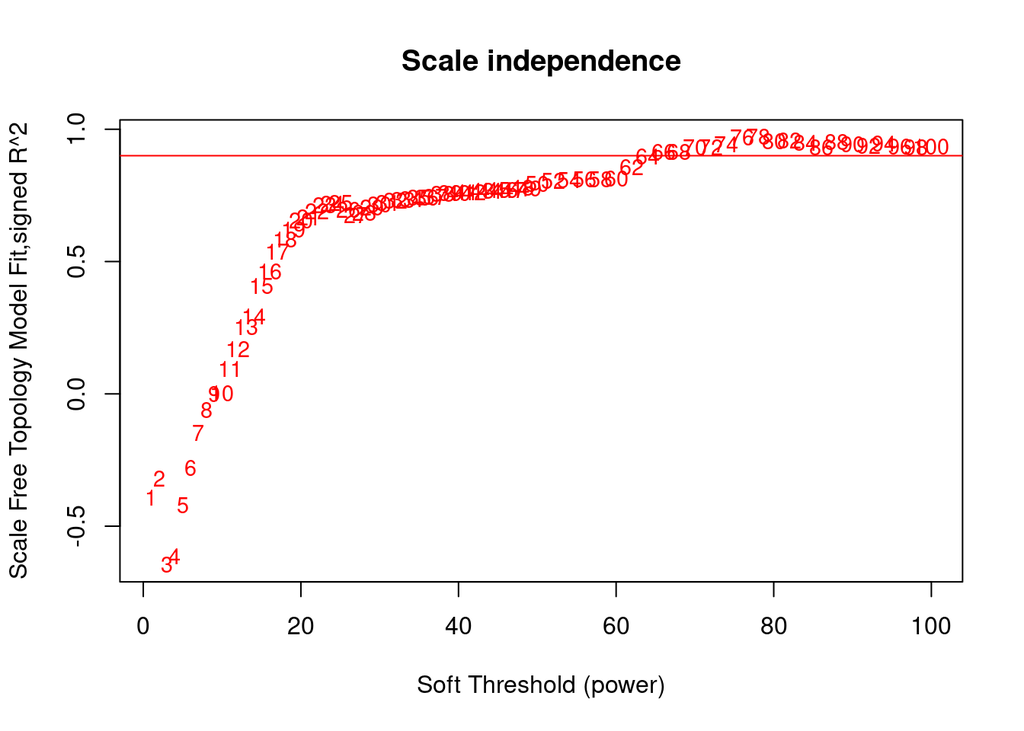

```r
plot(sft$fitIndices[,1], -sign(sft$fitIndices[,3])*sft$fitIndices[,2],
xlab="Soft Threshold (power)",ylab="Scale Free Topology Model Fit,signed R^2",type="n",
main = paste("Scale independence"));
text(sft$fitIndices[,1], -sign(sft$fitIndices[,3])*sft$fitIndices[,2],
labels=powers,cex=cex1,col="red");
# this line corresponds to using an R^2 cut-off of h
abline(h=0.90,col="red")
```

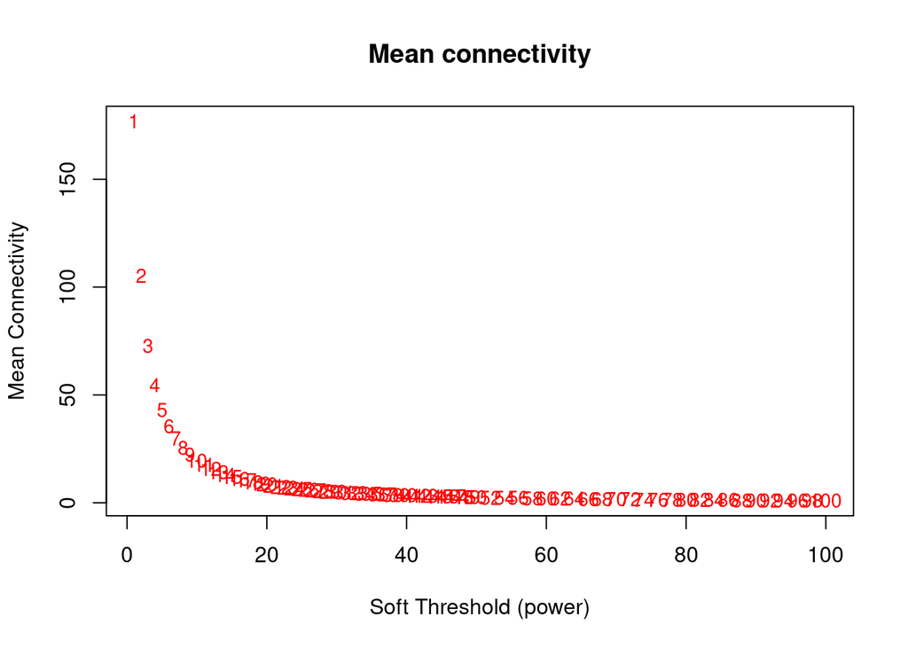

```r
# Mean connectivity as a function of the soft-thresholding power
plot(sft$fitIndices[,1], sft$fitIndices[,5],
xlab="Soft Threshold (power)",ylab="Mean Connectivity", type="n",
main = paste("Mean connectivity"))
text(sft$fitIndices[,1], sft$fitIndices[,5], labels=powers, cex=cex1,col="red")
```

## 2.a.2 One-step network construction and module detection

Constructing the gene network and identifying modules is now a simple function call:

```r
pw<-19
net = blockwiseModules(datExpr0, power = pw,
TOMType = "unsigned", minModuleSize = 30,
reassignThreshold = 0, mergeCutHeight = 0.25,
numericLabels = TRUE, pamRespectsDendro = FALSE,
saveTOMs = TRUE,
saveTOMFileBase = "femaleMouseTOM",
verbose = 3)
```

```
##  Calculating module eigengenes block-wise from all genes
##    Flagging genes and samples with too many missing values...
##     ..step 1
##  ..Working on block 1 .
##     TOM calculation: adjacency..
##     ..will not use multithreading.
##      Fraction of slow calculations: 0.000000
##     ..connectivity..
##     ..matrix multiplication (system BLAS)..
##     ..normalization..
##     ..done.
##    ..saving TOM for block 1 into file femaleMouseTOM-block.1.RData
##  ....clustering..
##  ....detecting modules..
##  ....calculating module eigengenes..
##  ....checking kME in modules..
##  ..merging modules that are too close..
##      mergeCloseModules: Merging modules whose distance is less than 0.25
##        Calculating new MEs...
```

We have chosen the soft thresholding power 19 , a relatively large minimum module size of 30, and a medium sensitivity (deepSplit=2) to cluster splitting. The parameter mergeCutHeight is the threshold for merging of modules. We have also instructed the function to return numeric, rather than color, labels for modules, and to save the Topological Overlap Matrix. The output of the function may seem somewhat cryptic, but it is easy to use. For example, net$colors contains the module assignment, and net$MEs contains the module eigengenes of the modules.

```r
 table(net$colors)
```

```
##
##   0   1   2   3   4   5   6
##   4 119  81  68  57  54  45
```

The dendrogram can be displayed together with the color assignment using the following code:

```r
# open a graphics window
sizeGrWindow(12, 9)
# Convert labels to colors for plotting
mergedColors = labels2colors(net$colors)
# Plot the dendrogram and the module colors underneath
```

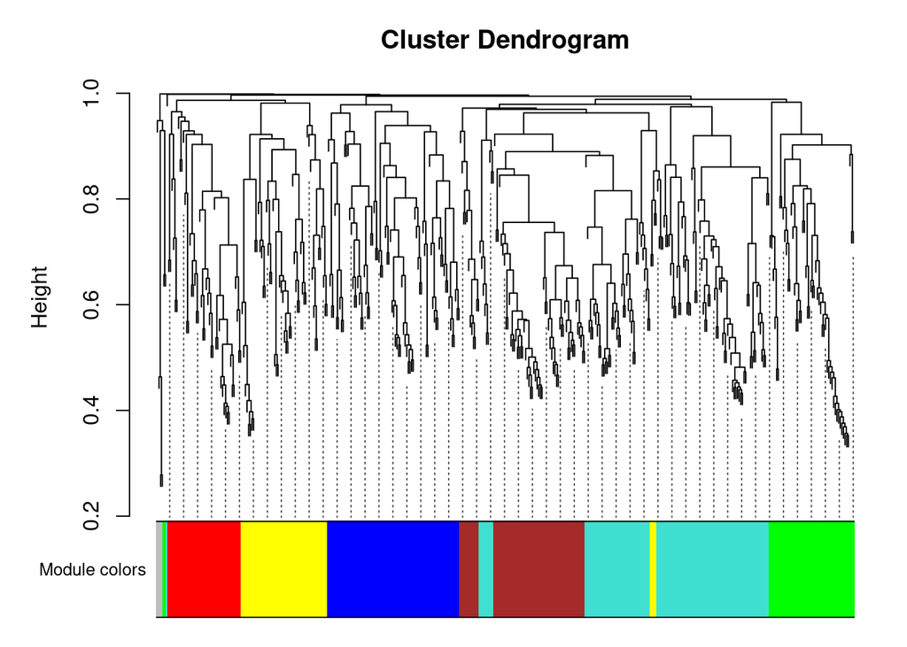

```r
plotDendroAndColors(net$dendrograms[[1]], mergedColors[net$blockGenes[[1]]],
"Module colors",
dendroLabels = FALSE, hang = 0.03,
addGuide = TRUE, guideHang = 0.05)
```

We note that if the user would like to change some of the tree cut, module membership, and module merging criteria, the package provides the function recutBlockwiseTrees that can apply modified criteria without having to recompute the network and the clustering dendrogram. This may save a sub-stantial amount of time. We now save the module assignment and module eigengene information necessary for subsequent analysis.

```r
moduleLabels = net$colors
moduleColors = labels2colors(net$colors)
MEs = net$MEs;
geneTree = net$dendrograms[[1]];
save(MEs, moduleLabels, moduleColors, geneTree,
file = "FemaleLiver-02-networkConstruction-auto.RData")
```

# 3 Relating modules to external clinical trait

## 3a Quantifying module–trait associations

In this analysis we would like to identify modules that are significantly associated with the measured clinical traits. Since we already have a summary profile (eigengene) for each module, we simply correlate eigengenes with external traits and look for the most significant associations

```r
# Define numbers of genes and samples
nGenes = ncol(datExpr0)
nSamples = nrow(datExpr0)
# Recalculate MEs with color labels
MEs0 = moduleEigengenes(datExpr0, moduleColors)$eigengenes
MEs = orderMEs(MEs0)
moduleTraitCor = cor(MEs, as.numeric(datTraits$grup), use = "p")
moduleTraitPvalue = corPvalueStudent(moduleTraitCor, nSamples)
```

Since we have a moderately large number of modules and traits, a suitable graphical representation will help in reading the table. We color code each association by the correlation value:

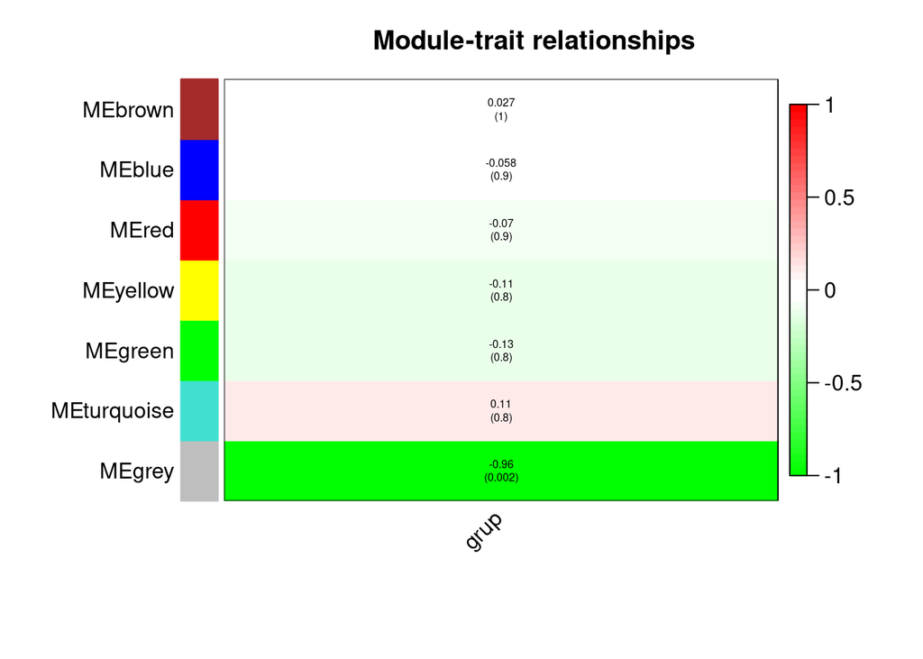

```r
# Will display correlations and their p-values
textMatrix = paste(signif(moduleTraitCor, 2), "\n(",
signif(moduleTraitPvalue, 1), ")", sep = "");
dim(textMatrix) = dim(moduleTraitCor)
par(mar = c(6, 8.5, 3, 3));
# Display the correlation values within a heatmap plot
labeledHeatmap(Matrix = moduleTraitCor,
xLabels = names(datTraits)[4],
yLabels = names(MEs),
ySymbols = names(MEs),
colorLabels = FALSE,
colors = greenWhiteRed(50),
textMatrix = textMatrix,
setStdMargins = FALSE,
cex.text = 0.5,
zlim = c(-1,1),
main = paste("Module-trait relationships"))
```

The analysis identifies the 1 significant module–trait associations. We will concentrate on **GRUP** as the trait of interest.